# Clase 3

Gráficos y Estadística Descriptiva

Barriola, Dotta y Weskler

3/5/2019

> Reiniciar Sesión

#### Cargamos las librerías a utilizar

```r
library(tidyverse) # tiene ggplot, dplyr, tidyr, y otros
```

# Estadística Descriptiva

La estadística descriptiva es la rama de la estadística que nos permite describir un conjunto de datos. Esto se puede realizar analizando una variable por vez: **analisis univariado** o analizando las relaciones entre 2 o mas variables: **analisis multivariado**. Para realizar esta tarea se usan medidas estadisticas y graficos. A continuacion, vamos a trabajar sobre ambas herramientas

## Medidas de resumen

Estas medidas nos permiten describir el comportamiento de una variable conociendo distintas caracteristicas de ella

Vamos a crear dos conjuntos de datos para ir aplucando cada una de estas medidas:

```r
# Estaturas de asistentes del curso
estaturas_1 <- c(1.60, 1.63, 1.68, 1.69, 1.70, 1.72, 1.72, 1.73, 1.74, 1.76, 1.78, 1.81, 1.83, 1.84, 1.85)
# Estaturas de asistentes del curso agregando un jugador de basquet
estaturas_2 <- c(estaturas_1, 2.19)
```

### Medidas de tendencia central

#### Promedio

Es una de las medidas para describir el centro de los datos

$\bar{x}= \frac{\sum\limits_{i=1}^N x_i}{N} = \frac{ x_1 + x_2+...+x_N}{N}$

La cuenta implica sumar todos los valores de la variable y luego dividir por la cantidad de observaciones

```r
# Calculemos la suma de las estaturas de la primera variable
suma_estaturas_1 <- sum(estaturas_1)
suma_estaturas_1
```

```
[1] 26.08
```

```r
# Calculemos cuantos elementos tiene nuestra variable
observaciones_estaturas_1 <- length(estaturas_1)
observaciones_estaturas_1
```

```
[1] 15
```

```r
# Calculemos el promedio
promedio_estaturas_1 <- suma_estaturas_1/observaciones_estaturas_1
promedio_estaturas_1
```

```
[1] 1.738667
```

El comando de esta medida estadistica es `mean()`

```r
# Calculamos el promedio de variable estaturas_1
mean(estaturas_1)
```

```
[1] 1.738667
```

```r
# Calculamos el promedio de variable estaturas_2
mean(estaturas_2)
```

```
[1] 1.766875
```

Notemos que el promedio difiere por casi 3 cm entre ambas variables. Esto se debe a que el promedio es una medida **sensible a outliers**.

Un **outlier** es una observacion con un valor atipico de la variable. En este caso, una estatura de 2.19 metros es un valor atipico para la variable estatura de un grupo de personas que asisten al curso.

Entonces el promedio, por su formula de calculo, cambia bastante su valor cuando hay valores atipicos (outliers) en nuestra variable. Por eso hay que tener cuidado cuando lo calculamos y detectar si es que existen outliers.

La función `mean()` no funciona cuando hay datos faltantes. Por eso es necesario agregar una especificación a la función para que no tome en consideración los datos faltantes a la hora de calcular el promedio.

```r
estaturas_faltantes <- c(estaturas_1,NA)
estaturas_faltantes
```

```
 [1] 1.60 1.63 1.68 1.69 1.70 1.72 1.72 1.73 1.74 1.76 1.78 1.81 1.83 1.84 1.85   NA
```

```r
mean(estaturas_faltantes)
```

```
[1] NA
```

```r
mean(estaturas_faltantes,na.rm = TRUE )
```

```
[1] 1.738667
```

**VENTAJA**

El **promedio** es una medida bastante conocida y sencilla de interpretar

**DESVENTAJA**

El **promedio** es una medida sensible a outliers

#### Moda

Es el valor que más se repite de la variable. R no dispone de una función base para calcular la moda, aunque hay librerías que si la tienen.

En el caso de nuestras dos variables la moda es 1.72

**VENTAJA**

La **moda** es una medida sencilla de interpretar

**DESVENTAJA**

La **moda** no es una medida muy util ni utilizada

#### Mediana

Si ordenamos los datos de menor a mayor, la *mediana* es aquel valor que separa a los datos en dos partes iguales: cada una contiene al 50% de los datos.

```r
# Calculemos cuantos elementos tiene nuestra variable
observaciones_estaturas_1 <- length(estaturas_1)
observaciones_estaturas_1
```

```
[1] 15
```

```r
# Tenemos 15 elementos (es una cantidad impar), busquemos en que posicion se encuentra la mediana
posicion_mediana_estatura_1 <- (observaciones_estaturas_1 + 1)/2
posicion_mediana_estatura_1
```

```
[1] 8
```

```r
# La mediana esta en la posicion 8, como nuestro vector ya esta ordenado de menor a mayor accedemos al dato en esa posicion
mediana_estaturas_1 <- estaturas_1[posicion_mediana_estatura_1]
mediana_estaturas_1
```

```
[1] 1.73
```

El comando de esta medida estadistica es `median()`

```r
# Mediana de la variable estatura
median(estaturas_1)
```

```
[1] 1.73
```

```r
# Mediana de la variable estatura_2
median(estaturas_2)
```

```
[1] 1.735
```

Notemos que a pesar de la presencia del dato atipico de la estatura del jugador de basquet, la mediana cambia muy poco. Esto sucede porque la mediana depende de la posicion de los observaciones y no de los valores de las mismas.

**VENTAJA**

La **mediana** es una medida no sensible a outliers

**DESVENTAJA**

La **mediana** es una medida menos conocida.

### Medidas de posición

Las medidas de posicion son aquellas que nos permiten conocer ciertos puntos (posiciones) de la variable ordenada de mayor a menor. Ya hemos visto una medida de posición: la **mediana** es una medida de posición ya que se encuentra en la mitad de los datos.

#### Maximo y Mínimo

El maximo es el mayor valor que toma la variable. El comando de esta medida estadistica es `max()`

```r
# Maximo de la variable estaturas_1
maximo_estaturas_1 <- max(estaturas_1)
# Maximo de la variable estaturas_2
maximo_estaturas_2 <- max(estaturas_2)
```

El minimo es el menor valor que toma la variable. El comando de esta medida estadistica es `min()`

```r
# Minimo de la variable estaturas_1
minimo_estaturas_1 <- min(estaturas_1)
# Minimo de la variable estaturas_2
minimo_estaturas_2 <- min(estaturas_2)
```

#### Cuantiles

Son ciertos valores del conjunto de observaciones de la variable ordenada que permiten subdividirlas en partes iguales. Los cuantiles mas conocidos son:

- **Mediana**: divide a las observaciones de la variable en 2 partes iguales (50% a izquierda y 50% a derecha de la mediana)
- **Cuartiles**: dividen a las observaciones en 4 partes iguales: el primer cuartil deja a izquierda el 25% de las observaciones (75% a la derecha), el segundo cuartil es la mediana (deja 50% a izquierda y 50% a derecha) y el tercer cuartil deja deja a izquierda el 75% de las observaciones (25% a la derecha)
- **Deciles**: dividen a las observaciones en 10 partes iguales: el primer decil deja a izquierda el 10% de las observaciones (90% a derecha)
- **Percentiles**: dividen a las observaciones en 100 partes iguales: el primer percentil deja a izquierda el 1% de las observaciones (99% a derecha)

El comando de esta medida estadistica es `quantile()`. Toma como primer argumento la variable y el segundo argumento es el porcentaje de observaciones que quedan a izquierda.

```r
# Calculamos el primer cuartil de estaturas 1. Entonces indicamos que deben quedar 25% de los datos a izquierda.
quantile(estaturas_1, 0.25)
```

```
  25%
1.695
```

```r
# Calculamos el primer cuartil de estaturas 2. Entonces indicamos que deben quedar 25% de los datos a izquierda.
quantile(estaturas_2, 0.25)
```

```
   25%
1.6975
```

```r
# Calculamos el septimo decil de estaturas 1. Entonces indicamos que deben quedar 70% de los datos a izquierda.
quantile(estaturas_1, 0.70)
```

```
  70%
1.776
```

```r
# Calculamos el septimo decil de estaturas 2. Entonces indicamos que deben quedar 70% de los datos a izquierda.
quantile(estaturas_2, 0.70)
```

```
  70%
1.795
```

```r
# Calculamos el percentil 17 de estaturas 1. Entonces indicamos que deben quedar 17% de los datos a izquierda.
quantile(estaturas_1, 0.17)
```

```
   17%
1.6838
```

```r
# Calculamos el percentil 17 de estaturas 2. Entonces indicamos que deben quedar 17% de los datos a izquierda.
quantile(estaturas_2, 0.17)
```

```
   17%
1.6855
```

### Medidas de dispersión

#### Rango

Es la diferencia entre el valor maximo y minimo.

```r
# Calculamos el rango de estaturas 1
rango_estaturas_1 <- maximo_estaturas_1 - minimo_estaturas_1
rango_estaturas_1
```

```
[1] 0.25
```

```r
# Calculamos el rango de estaturas 2
rango_estaturas_2 <- maximo_estaturas_2 - minimo_estaturas_2
rango_estaturas_2
```

```
[1] 0.59
```

El comando `range()` nos devuelve el minimo y maximo de nuestra variable y no la diferencia entre ellos

```r
range(estaturas_1)
```

```
[1] 1.60 1.85
```

#### Varianza

Si tenemos un conjunto de observaciones muy cercanas al promedio, la varianza va a ser pequeña y cercana a cero. En cambio, si tenemos un conjunto de observaciones que estan lejos del promedio, la varianza va a ser muy grande.

El comando de esta medida estadistica es `var()`.

```r
# Varianza de estatura 1
varianza_estaturas_1 <- var(estaturas_1)
varianza_estaturas_1
```

```
[1] 0.005526667
```

```r
# Varianza de estatura 2
varianza_estaturas_2 <- var(estaturas_2)
varianza_estaturas_2
```

```
[1] 0.01788958
```

La interpretacion de la varianza depende de las unidad en la cual esta medida la variable

```r
# Varianza de estatura 1
varianza_estaturas_1
```

```
[1] 0.005526667
```

```r
var(estaturas_1*100)
```

```
[1] 55.26667
```

Entonces es una medida util para comparar la variabilidad/dispersion de variables que estan medidas en la misma unidad, como por ejemplo la estatura medida en metros, los sueldos medidos en pesos. No tiene sentido comparar la varianza entre varaibles que esten medidas en distintas unidades.

## Estadística Descriptiva con Tidyverse

Vamos a utilizar las medidas de resumen que vimos junto a las funciones de Tidyverse.

Trabajaremos con un conjunto de datos del portal de datos abiertos de Argentina. Es un dataset que contiene información sobre el programa ProHuerta para febrero de 2019 https://datos.gob.ar/dataset/desarrollo-social-programa-prohuerta

```r
#Leemos el archivo
huertas <- read.csv('~/ATR-2019/Fuentes/dahuertas2.csv',sep =';', header = TRUE, stringsAsFactors = FALSE)
# Revisamos la estructura del dataset
glimpse(huertas)
```

```
Observations: 516
Variables: 8
$ PERIODO                                <chr> "2019-02-01", "2019-02-01", "2019-02-01", "2019-02-01", "2019-02-01", "2019-02-0...
$ ID.PROVINCIA                           <int> 6, 6, 6, 6, 6, 6, 6, 6, 6, 6, 6, 6, 6, 6, 6, 6, 6, 6, 6, 6, 6, 6, 6, 6, 6, 6, 6,...
$ PROVINCIA                              <chr> "BUENOS AIRES", "BUENOS AIRES", "BUENOS AIRES", "BUENOS AIRES", "BUENOS AIRES", ...
$ ID.DEPARTAMENTO                        <chr> "06854", "06588", "06007", "06014", "06021", "06077", "06042", "06049", "06056",...
$ DEPARTAMENTO                           <chr> "25 DE MAYO", "9 DE JULIO", "ADOLFO ALSINA", "ADOLFO GONZALES CHAVES", "ALBERTI"...
$ HUERTAS.FAMILIARES                     <int> 988, 0, 333, 197, 318, 101, 183, 1219, 589, 646, 581, 381, 2432, 696, 902, 851, ...
$ HUERTAS.ESCOLARES                      <int> 44, 13, 32, 13, 16, 1, 6, 30, 18, 25, 45, 14, 32, 11, 44, 15, 32, 2, 5, 28, 15, ...
$ HUERTAS.COMUNITARIAS.E.INSTITUCIONALES <int> 3, 0, 12, 1, 0, 7, 2, 20, 16, 15, 18, 8, 31, 5, 4, 8, 7, 0, 3, 1, 1, 20, 2, 15, ...
```

Vemos que tenemos 8 variables y 516 observaciones. Tenemos informacion de la provincia, el departamento, la cantidad de huertas familiares, escolares y comunitarias e institucionales.

Cada observacion es un departamento en Argentina

#### Medidas de resumen generales

Supongamos que estamos somos un grupo de analistas que nos interesa analizar el comportamiento de la variable **huertas escolares**. Utilizamos el comando `summarise()` para obtener distintas medidas de resumen sobre la variable de interes:

```r
resumen_huertas_escolares <- huertas %>%
  summarise(total_huertas_esc = sum(HUERTAS.ESCOLARES), # total de huertas escolares
            promedio_huertas_esc = mean(HUERTAS.ESCOLARES), # promedio de huertas escolares
            mediana_huertas_esc = median(HUERTAS.ESCOLARES),  # mediana de huertas escolares
            max_huertas_esc = max(HUERTAS.ESCOLARES), # maximo de huertas escolares
            min_huertas_esc = min(HUERTAS.ESCOLARES), # minimo de huertas escolares
            rango_huertas_esc = max_huertas_esc -min_huertas_esc, # rango de huertas escolares
            varianza_huertas_esc = var(HUERTAS.ESCOLARES)) # varianza de huertas escolares
resumen_huertas_escolares
```

| total_huertas_esc | promedio_huertas_esc | mediana_huertas_esc | max_huertas_esc | min_huertas_esc | rango_huertas_esc | varianza_huertas_esc |
| --- | --- | --- | --- | --- | --- | --- |
| 14403 | 27.91279 | 20 | 211 | 0 | 211 | 749.1594 |

Con esto podemos contestar, entre otras preguntas:

- ¿Cuántas huertas escolares hay en el país?
- ¿Cuántas huertas escolares hay en promedio en los departamentos del país?
- ¿Cuál es la mayor cantidad de huertas escolares entre todos los departamentos del país? ¿Y la menor?

#### Medidas de resumen por provincia

Ahora queremos profundizar en nuestro análisis y calcular las medidas de resumen anteriores para cada provincia:

```r
resumen_prov_huertas_escolares <- huertas %>% group_by(PROVINCIA) %>%
  summarise(cantidad_distritos = n(), # cantidad de departamentos en el programa
            total_huertas_esc = sum(HUERTAS.ESCOLARES), # total de huertas escolares
            promedio_huertas_esc = mean(HUERTAS.ESCOLARES), # promedio de huertas escolares
            mediana_huertas_esc = median(HUERTAS.ESCOLARES),  # mediana de huertas escolares
            max_huertas_esc = max(HUERTAS.ESCOLARES), # maximo de huertas escolares
            min_huertas_esc = min(HUERTAS.ESCOLARES), # minimo de huertas escolares
            rango_huertas_esc = max_huertas_esc -min_huertas_esc, # rango de huertas escolares
            varianza_huertas_esc = var(HUERTAS.ESCOLARES)) # varianza de huertas escolares
resumen_prov_huertas_escolares
```

| PROVINCIA | cantidad_distritos | total_huertas_esc | promedio_huertas_esc | mediana_huertas_esc | max_huertas_esc | min_huertas_esc | rango_huertas_esc | varianza_huertas_esc |
| --- | --- | --- | --- | --- | --- | --- | --- | --- |
| BUENOS AIRES | 128 | 2179 | 17.023438 | 13.5 | 53 | 0 | 53 | 160.62149 |
| CAPITAL FEDERAL | 1 | 75 | 75.000000 | 75.0 | 75 | 75 | 0 | NA |
| CATAMARCA | 17 | 238 | 14.000000 | 15.0 | 27 | 0 | 27 | 68.75000 |
| CHACO | 26 | 1971 | 75.807692 | 74.5 | 148 | 0 | 148 | 1134.88154 |
| CHUBUT | 14 | 134 | 9.571429 | 6.0 | 32 | 0 | 32 | 91.49451 |
| CORDOBA | 28 | 1203 | 42.964286 | 47.0 | 99 | 0 | 99 | 906.33201 |
| CORRIENTES | 26 | 456 | 17.538462 | 16.0 | 46 | 0 | 46 | 148.97846 |
| ENTRE RIOS | 18 | 493 | 27.388889 | 27.0 | 48 | 0 | 48 | 126.60458 |
| FORMOSA | 10 | 778 | 77.800000 | 85.5 | 110 | 41 | 69 | 495.51111 |
| JUJUY | 16 | 379 | 23.687500 | 20.0 | 59 | 0 | 59 | 507.02917 |

[output cut: 14 more lines]

Ahora podemos contestar las siguientes preguntas:

- ¿Cuáles son las 3 provincias con mayor cantidad de huertas escolares? ¿Y las 3 con menor cantidad?
- ¿Cuál es la provincia qué, en promedio, tiene mayor cantidad de huertas? ¿Y la que menos tiene?
- ¿Qué provincia tiene el distrito con mayor cantidad de huertas escolares?
- ¿Cuáles provincias no tienen distritos sin huertas escolares?

#### Dataset expandido

```r
huertas_expandido <- huertas %>% mutate(huertas_totales = HUERTAS.FAMILIARES + HUERTAS.ESCOLARES + HUERTAS.COMUNITARIAS.E.INSTITUCIONALES,
                                        porc_huertas_familiares = HUERTAS.FAMILIARES/huertas_totales * 100,
                                        porc_huertas_escolares = HUERTAS.ESCOLARES/huertas_totales * 100,
                                        porc_huertas_comunitarias = HUERTAS.COMUNITARIAS.E.INSTITUCIONALES/huertas_totales * 100)
glimpse(huertas_expandido)
```

```
Observations: 516
Variables: 12
$ PERIODO                                <chr> "2019-02-01", "2019-02-01", "2019-02-01", "2019-02-01", "2019-02-01", "2019-02-0...
$ ID.PROVINCIA                           <int> 6, 6, 6, 6, 6, 6, 6, 6, 6, 6, 6, 6, 6, 6, 6, 6, 6, 6, 6, 6, 6, 6, 6, 6, 6, 6, 6,...
$ PROVINCIA                              <chr> "BUENOS AIRES", "BUENOS AIRES", "BUENOS AIRES", "BUENOS AIRES", "BUENOS AIRES", ...
$ ID.DEPARTAMENTO                        <chr> "06854", "06588", "06007", "06014", "06021", "06077", "06042", "06049", "06056",...
$ DEPARTAMENTO                           <chr> "25 DE MAYO", "9 DE JULIO", "ADOLFO ALSINA", "ADOLFO GONZALES CHAVES", "ALBERTI"...
$ HUERTAS.FAMILIARES                     <int> 988, 0, 333, 197, 318, 101, 183, 1219, 589, 646, 581, 381, 2432, 696, 902, 851, ...
$ HUERTAS.ESCOLARES                      <int> 44, 13, 32, 13, 16, 1, 6, 30, 18, 25, 45, 14, 32, 11, 44, 15, 32, 2, 5, 28, 15, ...
$ HUERTAS.COMUNITARIAS.E.INSTITUCIONALES <int> 3, 0, 12, 1, 0, 7, 2, 20, 16, 15, 18, 8, 31, 5, 4, 8, 7, 0, 3, 1, 1, 20, 2, 15, ...
$ huertas_totales                        <int> 1035, 13, 377, 211, 334, 109, 191, 1269, 623, 686, 644, 403, 2495, 712, 950, 874...
$ porc_huertas_familiares                <dbl> 95.45894, 0.00000, 88.32891, 93.36493, 95.20958, 92.66055, 95.81152, 96.05989, 9...
$ porc_huertas_escolares                 <dbl> 4.25120773, 100.00000000, 8.48806366, 6.16113744, 4.79041916, 0.91743119, 3.1413...
$ porc_huertas_comunitarias              <dbl> 0.28985507, 0.00000000, 3.18302387, 0.47393365, 0.00000000, 6.42201835, 1.047120...
```

# Gráficos

Son muy utilizados para visualizar una o mas variables de los conjuntos de datos.

## Gráficos Básicos en R

Rbase tiene algunos comandos genéricos para realizar gráficos, que se adaptan al tipo de información que se le pide graficar, por ejemplo:

- plot()
- hist()

```r
# iris es un set de datos clásico, que ya viene incorporado en R
iris
```

| Sepal.Length | Sepal.Width | Petal.Length | Petal.Width | Species |
| --- | --- | --- | --- | --- |
| 5.1 | 3.5 | 1.4 | 0.2 | setosa |
| 4.9 | 3.0 | 1.4 | 0.2 | setosa |
| 4.7 | 3.2 | 1.3 | 0.2 | setosa |
| 4.6 | 3.1 | 1.5 | 0.2 | setosa |
| 5.0 | 3.6 | 1.4 | 0.2 | setosa |
| 5.4 | 3.9 | 1.7 | 0.4 | setosa |
| 4.6 | 3.4 | 1.4 | 0.3 | setosa |
| 5.0 | 3.4 | 1.5 | 0.2 | setosa |
| 4.4 | 2.9 | 1.4 | 0.2 | setosa |
| 4.9 | 3.1 | 1.5 | 0.1 | setosa |

[output cut: 140 more lines]

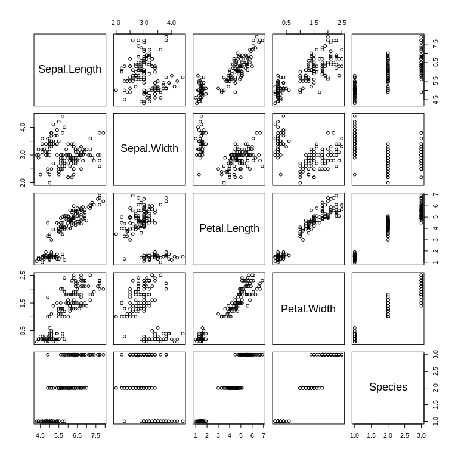

```r
plot(iris)
```

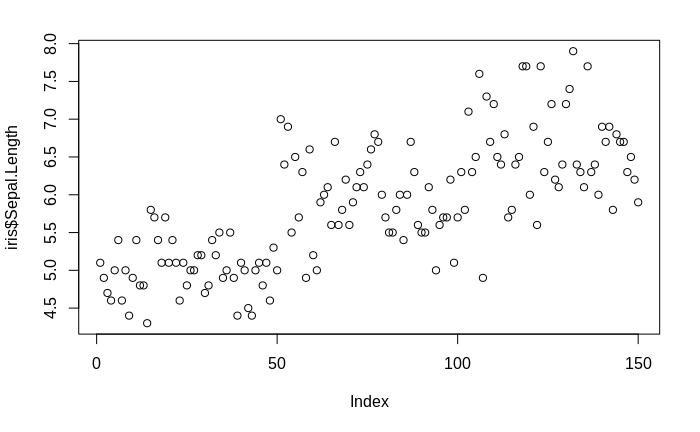

```r
#Al especificar una variable, puedo ver el valor que toma cada uno de sus registros (Index)
plot(iris$Sepal.Length,type = "p") # Un punto por cada valor
```

Los gráficos del R base son útiles para escribir de forma rápida y obtener alguna información mientras trabajamos. Muchos paquetes estadísticos permiten mostrar los resultados de forma gráfica con el comando plot (por ejemplo, las regresiones lineales `lm()`).

Sin embargo, existen librerías mucho mejores para crear gráficos de nivel de publicación. La más importante es **ggplot2**, que a su vez tiene extensiones mediante otras librerías.

## [Ggplot2](http://ggplot2.tidyverse.org/reference/)

ggplot tiene su sintaxis propia. La idea central es pensar los gráficos como una sucesión de capas, que se construyen una a la vez.

- El operador **`+`** nos permite incorporar nuevas capas al gráfico.
- El comando `ggplot()` nos permite definir la fuente de **datos** y las **variables** que determinaran los ejes del grafico (x,y), así como el color y la forma de las líneas o puntos,etc.
- Las sucesivas capas nos permiten definir:
  - Uno o más tipos de gráficos (de columnas, `geom_col()`, de línea, `geom_line()`, de puntos,`geom_point()`, boxplot, `geom_boxplot()`)
  - Títulos `labs()`
  - Estilo del gráfico `theme()`
  - Escalas de los ejes `scale_y_continuous`,`scale_x_discrete`
  - División en subconjuntos `facet_wrap()`,`facet_grid()`

ggplot tiene **muchos** comandos, y no tiene sentido saberlos de memoria, es siempre útil reutilizar gráficos viejos y tener a mano el [machete](https://www.rstudio.com/wp-content/uploads/2016/11/ggplot2-cheatsheet-2.1.pdf).

## Gráfico de Puntos o de Dispersión

A continuación veremos un gráfico de varias capas de construcción, con su correspondiente porción de código. En el mismo buscaremos visualizar, a partir de la base de datos **iris** la relación entre el ancho y el largo de los petalos, mediante un gráfico de puntos o de dispersión

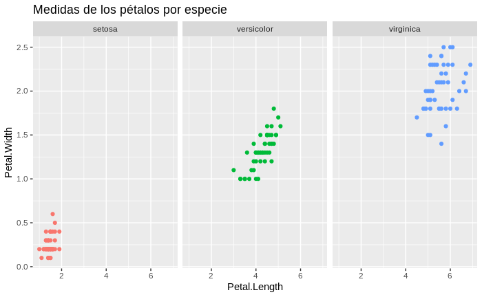

```r
ggplot(data = iris, aes(x = Petal.Length, Petal.Width, color = Species))+ #Datos y variables
  geom_point()+ # Tipo de grafico
  labs(title = "Medidas de los pétalos por especie")+ #Titulo
  theme(legend.position = 'none')+ #Eliminar la leyenda
  facet_wrap(~Species) # Dividir por la especie
```

### Capas del Gráfico

Veamos ahora, el “paso a paso” del armado del mismo.

En primera instancia solo defininimos los ejes.

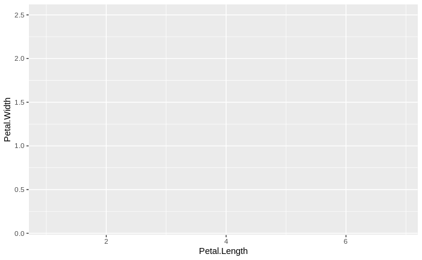

```r
g <- ggplot(data = iris, aes(x = Petal.Length,y= Petal.Width))
g
```

Notemos que los ejes tienen los nombres y valores de las variables, pero todavía no hay ningún gráfico. Ahora definimos el tipo de gráfico, en este caso, `geom_point` es un gráfico de puntos o dispersión.

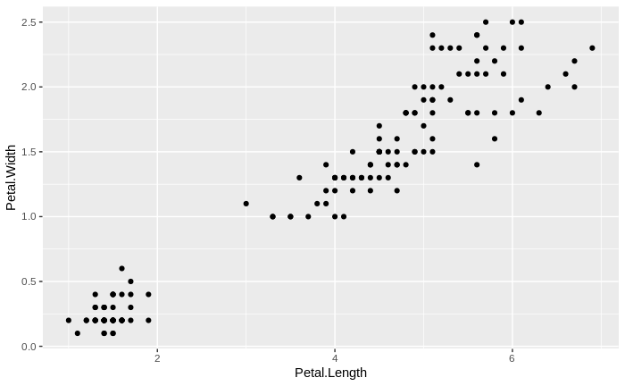

```r
g <- g +  geom_point()
g
```

Sabemos que hay 3 especies distintas en el dataset. Podemos agregar esta variable adicional con el color. Así nos queda un color para cada Especie.

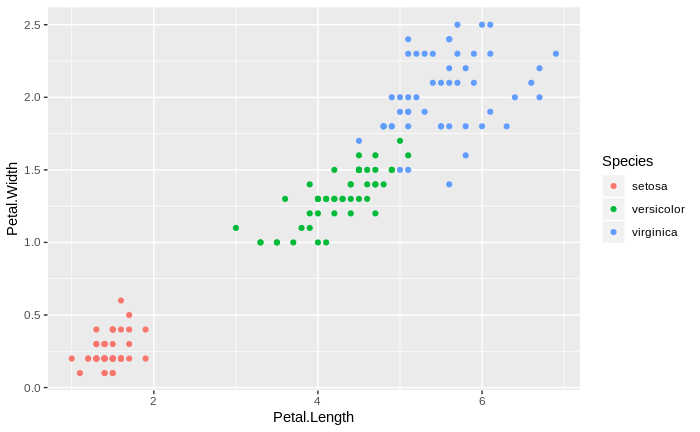

```r
g <- ggplot(data = iris, aes(x = Petal.Length, Petal.Width, color = Species))  +  geom_point()
g
```

Las siguientes tres capas nos permiten respectivamente:

- Definir el título del gráfico
- Quitar la leyenda
- Abrir el gráfico en tres fragmentos, uno para cada especie

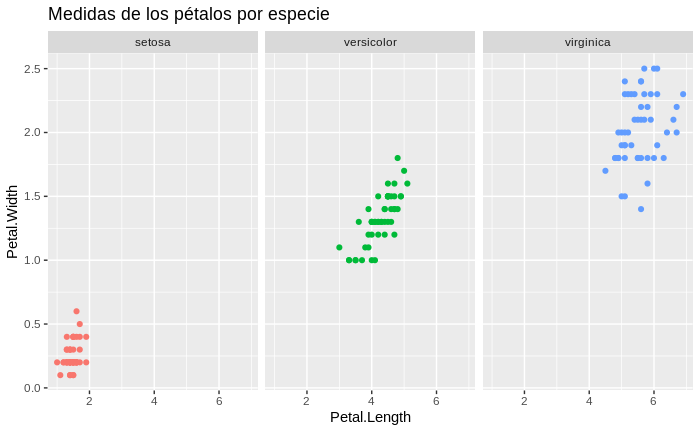

```r
g <- g +
  labs(title = "Medidas de los pétalos por especie")+
  theme(legend.position = 'none')+
  facet_wrap(~Species)
g
```